title: “Kaia’s A4 Report Title” author: “Kaia Armas” date: ‘11,17,2022’ output: html_document

## Abstract

I compared the data and was able to make serveral findings. I looked at a dataset of demographic information and then invetigated and then found out the differences between the black and white jail population. I was able to find out how much more black people are in prison than white people. Using the map I was able to see the differences between different states to see how see roughly how many black people were in jail in each state. It was really interesting to see because there were some states that I didn’t think would have a high jail population of blacks.

## Introduction

The social issues related to this data set are that there is a good variety of minority groups getting imprisoned as well as getting jail time.It raises concerns since there are more colored people in jail and prison. There is more black people than any other racial group. I think that black people feel more targeted and are getting jail time. The indirect and direct stakeholders are impacted by research by drawing upon conclusions quickly. The stakeholders become more aware of everyone in jail/prison and are aware. The stakeholders are writers, journalists, and bloggers. There are different people interpreting different parts of the data set. The two questions I answered are: What is the difference between Black and White jail rate from 1990-2018? and How does the Black Jail population vary by State?.

## Data Summary

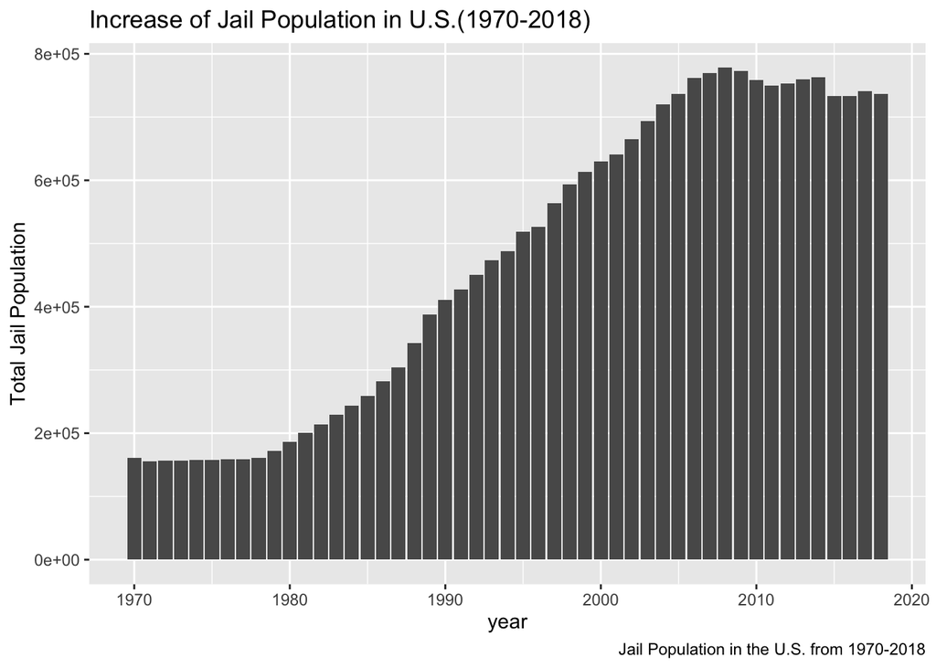

```r
plot_jail_pop_for_us()
```

This graph shows that the Total Jail population got higher as the years increased. There is a significant difference between the Jail Population in 1970 compared to 2018. Form 1980 to around mid 2000’s there was steep increase.It was pretty consistant in the 70’s before the increase and leveled off before in the mid 2000’s.

## Growth of Prison Population by State

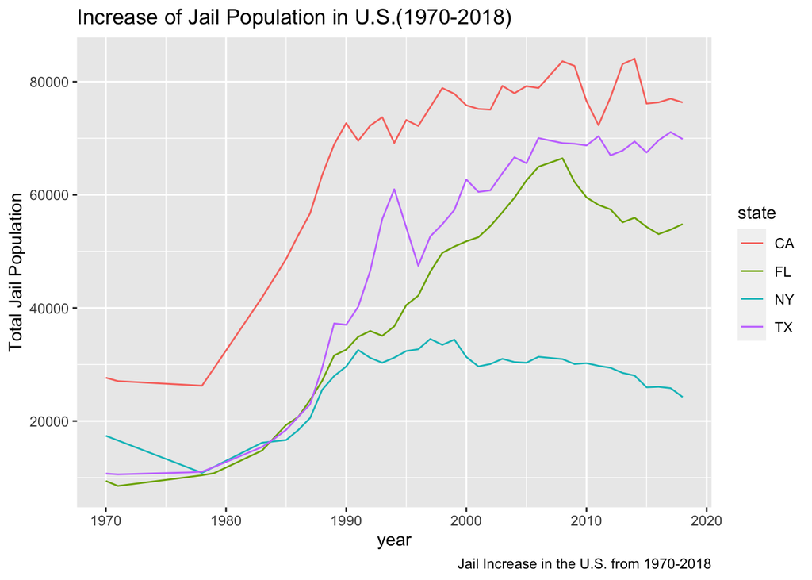

```r
plot_jail_pop_by_states(c("NY", "CA", "FL","TX"))
```

## Section 5:Black Jail Rate vs White Jail Rate

[figure not shown]

```r
plot_demo()
```

## Section 6: Black Jail Rate by State

```r
plot_demo_states()
```

[interactive chart not shown]

How does the Black Jail population vary by State? The Black Jail Population is pretty high in some of the states but most of them are less than 3000. The dark red states show the highest that it can get which is 3000+, the orange states are somewhere in the middle, and the yellow states have a very low population. It was interesting to see how the different states vary with the black jail population. I feel like the ones with the most jail populations set pretty spefic rules compared to the rest of the states with less jail population.